# Linear Regression

Italo Batista

7 de outubro de 2018

Nesta análise iremos explorar dados sobre as votações que candidatos à Câmara Federal de Deputados receberam nos anos de 2006 e 2010. A nossa tarefa é usar Regressão Linear para explicar essas votações. Esses dados foram extraídos do [TSE](http://www.tse.jus.br/hotSites/pesquisas-eleitorais/index.html), pré-processados e contemplam informações sobre aproximadamente 7.300 candidatos.

## Importando dados

```r
library(here)
library(dplyr)
library(readr)
here::set_here()
elections_2006_2010 = readr::read_csv(
  here::here("../data/tse/eleicoes_2006_e_2010.csv"),
  local=readr::locale("br"),
  col_types = cols(
    ano = col_integer(),
    sequencial_candidato = col_integer(),
    quantidade_doacoes = col_integer(),
    quantidade_doadores = col_integer(),
    total_receita = col_double(),
    media_receita = col_double(),
    recursos_de_outros_candidatos.comites = col_double(),
    recursos_de_pessoas_fisicas = col_double(),
    recursos_de_pessoas_juridicas = col_double(),
    recursos_proprios = col_double(),
    `recursos_de_partido_politico` = col_double(),
    quantidade_despesas = col_integer(),
    quantidade_fornecedores = col_integer(),
    total_despesa = col_double(),
    media_despesa = col_double(),
    votos = col_integer(),
    .default = col_character())
  )
```

## Conhecendo os dados

```r
elections_2006_2010 %>%
  glimpse()
```

```
Observations: 7,476
Variables: 24
$ ano                                   <int> 2006, 2006, 2006, 2006, 2006, 2006, 2006, 2006, 2006, 2006, 2006, 2006, 2006, 2006, 2006, 2006, 2...
$ sequencial_candidato                  <int> 10001, 10002, 10002, 10002, 10003, 10003, 10003, 10003, 10003, 10004, 10004, 10004, 10004, 10004,...
$ nome                                  <chr> "JOSÉ LUIZ NOGUEIRA DE SOUSA", "LOIVA DE OLIVEIRA", "MARIA DALVA DE SOUZA FIGUEIREDO", "ROMALDO M...
$ uf                                    <chr> "AP", "RO", "AP", "MS", "RO", "PI", "MS", "MG", "DF", "AP", "RO", "PR", "RS", "MG", "RO", "MG", "...
$ partido                               <chr> "PT", "PT", "PT", "PRONA", "PT", "PCO", "PRONA", "PPS", "PAN", "PT", "PT", "PPS", "PT", "PPS", "P...
$ quantidade_doacoes                    <int> 6, 13, 17, 6, 48, 6, 14, 2, 5, 2, 68, 13, 61, 24, 13, 4, 1, 67, 2, 1, 4, 29, 6, 8, 2, 1, 12, 1, 5...
$ quantidade_doadores                   <int> 6, 13, 16, 6, 48, 6, 7, 2, 3, 2, 65, 13, 54, 23, 13, 4, 1, 64, 2, 1, 4, 27, 6, 7, 2, 1, 11, 1, 4,...
$ total_receita                         <dbl> 16600.00, 22826.00, 158120.80, 3001.12, 119820.00, 1771.21, 1231.00, 70000.00, 11570.00, 6065.00,...
$ media_receita                         <dbl> 2766.67, 1755.85, 9301.22, 500.19, 2496.25, 295.20, 87.93, 35000.00, 2314.00, 3032.50, 1635.56, 2...
$ recursos_de_outros_candidatos.comites <dbl> 0.00, 6625.00, 2250.00, 0.00, 0.00, 0.00, 0.00, 0.00, 0.00, 6065.00, 9575.00, 1375.50, 6295.10, 0...
$ recursos_de_pessoas_fisicas           <dbl> 9000.00, 15000.00, 34150.00, 1150.00, 50878.00, 0.00, 1231.00, 0.00, 0.00, 0.00, 59143.20, 4500.0...
$ recursos_de_pessoas_juridicas         <dbl> 6300.00, 1000.00, 62220.80, 1101.12, 0.00, 0.00, 0.00, 0.00, 0.00, 0.00, 26000.00, 12500.00, 1764...
$ recursos_proprios                     <dbl> 1300.00, 201.00, 59500.00, 750.00, 68942.00, 1771.21, 0.00, 70000.00, 0.00, 0.00, 16500.00, 9370....
$ recursos_de_partido_politico          <dbl> 0, 0, 0, 0, 0, 0, 0, 0, 11570, 0, 0, 0, 0, 3502, 0, 0, 0, 0, 0, 0, 0, 0, 0, 0, 0, 1125, 0, 0, 0, ...
$ quantidade_despesas                   <int> 14, 24, 123, 8, 133, 9, 17, 332, 51, 10, 68, 52, 181, 61, 44, 28, 1, 330, 2, 13, 70, 47, 22, 8, 2...
$ quantidade_fornecedores               <int> 14, 23, 108, 8, 120, 9, 10, 278, 33, 10, 67, 49, 153, 38, 41, 22, 1, 252, 2, 13, 70, 44, 16, 4, 2...
$ total_despesa                         <dbl> 16583.60, 20325.99, 146011.70, 3001.12, 116416.64, 1771.21, 696.91, 66016.95, 7570.00, 6060.42, 1...
$ media_despesa                         <dbl> 1184.54, 846.92, 1187.09, 375.14, 875.31, 196.80, 40.99, 198.85, 148.43, 606.04, 1629.68, 532.35,...
$ cargo                                 <chr> "DEPUTADO FEDERAL", "DEPUTADO FEDERAL", "DEPUTADO FEDERAL", "DEPUTADO FEDERAL", "DEPUTADO FEDERAL...
$ sexo                                  <chr> "MASCULINO", "FEMININO", "FEMININO", "MASCULINO", "MASCULINO", "MASCULINO", "MASCULINO", "MASCULI...
$ grau                                  <chr> "ENSINO MÉDIO COMPLETO", "SUPERIOR COMPLETO", "SUPERIOR COMPLETO", "ENSINO MÉDIO INCOMPLETO", "EN...
$ estado_civil                          <chr> "CASADO(A)", "SOLTEIRO(A)", "VIÚVO(A)", "CASADO(A)", "CASADO(A)", "CASADO(A)", "CASADO(A)", "CASA...
$ ocupacao                              <chr> "VEREADOR", "SERVIDOR PÚBLICO ESTADUAL", "PEDAGOGO", "MILITAR REFORMADO", "DEPUTADO", "SERVIDOR P...
$ votos                                 <int> 8579, 2757, 17428, 1193, 29401, 1822, 317, 2591, 113, 2551, 34631, 26856, 106659, 1859, 3752, 834...
```

Pela descrição, esperamos que algumas variáveis, como `nome` e `sequencial_candidato`, não influenciem na quantidade de votos. A var `cargo` também não influencia, pois todos as obersações tratam de deputados federais. No nosso primeiro modelo, não iremos utilizar tais variáveis, dado que já esperamos nenhum relacionamento entre elas e a variável `voto`.

Vamos plotar a distribuição das variáveis, desconsiderando as variáveis categóricas.

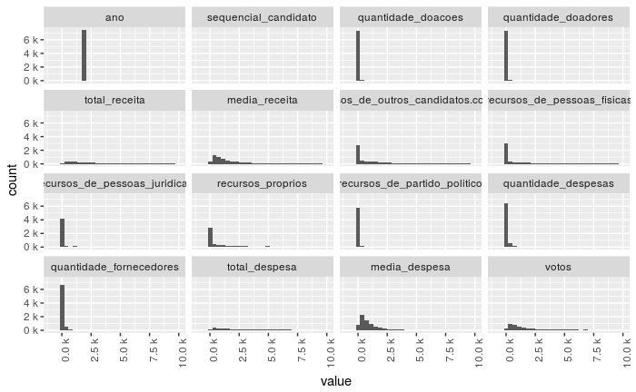

```r
library(reshape2)
library(ggplot2)
library(scales)
remove_categorical_vars_converted = function(data) {
  return(
    data %>%
      select(-c(nome, uf, partido, cargo, sexo, grau, estado_civil, ocupacao))
  )
}
reshaped_data =
  reshape2::melt(
    elections_2006_2010 %>%
      remove_categorical_vars_converted)
ggplot2::ggplot(reshaped_data, aes(x = value)) +
  facet_wrap(~variable) +
  geom_histogram() +
  scale_y_continuous(label = scales::unit_format(unit = "k", scale = 1e-3))  +
  scale_x_continuous(label = scales::unit_format(unit = "k", scale = 1e-3), limits = c(-1000, 10000))  +
  theme(axis.text.x = element_text(angle = 90, hjust = 1))
```

No geral a maioria dos valores das variáveis se concentram ao redor de 0. Esse não é o caso de votos. Votos tem um comportamento mais parecido com total_despesa, media_despesa, total_receita e media_receita.

## Pré-processando

Convertendo vars categóricas em numéricas

```r
categorics_to_numerics = function(dataframe) {
  converted_cols = dataframe %>%
    dplyr::mutate(
    uf = as.numeric(as.factor(uf)),
    nome = as.numeric(as.factor(nome)),
    partido = as.numeric(as.factor(partido)),
    grau = as.numeric(as.factor(grau)),
    estado_civil = as.numeric(as.factor(estado_civil)),
    ocupacao = as.numeric(as.factor(ocupacao)),
    cargo = as.numeric(as.factor(cargo)),
    sexo = as.numeric(as.factor(sexo)),
    sequencial_candidato = as.numeric(as.factor(sequencial_candidato)))
  return(converted_cols)
}
elections_2006_2010 = elections_2006_2010 %>% categorics_to_numerics
```

Filtrando para gerar dois datasets, um para cada ano (2006 e 2010).

```r
elections_2006 = elections_2006_2010 %>% filter(ano == 2006)
elections_2010 = elections_2006_2010 %>% filter(ano == 2010)
```

## Treino, Validação e Teste

Criando uma função auxiliar para dividir um dataset de entrada em três de saída (treino, validação e teste).

```r
# create a train, validation and tests from the original data frame
create_train_validate_test = function(dataframe) {
  assignment = sample(
    1:3, size = nrow(elections_2010),
    prob = c(0.6, 0.2, 0.2), replace = TRUE)
  smp_train = dataframe[assignment == 1, ]
  smp_valid = dataframe[assignment == 2, ]
  smp_test = dataframe[assignment == 3, ]

  return(list(smp_train, smp_valid, smp_test))
}
```

## 1. Um modelo de regressão múltipla com todas as variáveis é plausível para explicar a variação em y (número de votos)?

De certo modo já respondemos a essa pergunta. Mais acima, avaliamos que as variáveis abaixo não seriam significantes para a predição:

- sequencial_candidato
- nome
- cargo

Ainda pode haver outras variáveis que também não são boas preditoras. Para poder identificá-las, iremos gerar o modelo e posteriormente avaliá-lo.

### Construindo o modelo

#### 1.1 Em 2006

Dividindo os dados e criando o set para treino do modelo:

```r
## set seed to make partition reproducible
set.seed(123)
splitted = create_train_validate_test(elections_2006)
train_2006 = splitted[[1]]
valid_2006 = splitted[[2]]
test_2006 = splitted[[3]]
```

Função para não usar as variáveis que já julgamos como ruins preditoras.

```r
remove_non_related_vars = function(data) {
    return(
    data %>%
      select(-c(ano, nome, sequencial_candidato, cargo))
  )
}
```

Instanciando o modelo:

```r
regression_linear_model_all_vars = function(train_data) {
  filtered_traind_data = train_data %>% remove_non_related_vars
  model_all_vars_2006 = lm(data = filtered_traind_data, votos ~ .)
  return(model_all_vars_2006)
}
model_all_vars_2006 = regression_linear_model_all_vars(train_2006)
```

#### 1.2 Para eleições de 2010.

Dividindo os dados e criando o set para treino do modelo:

```r
splitted = create_train_validate_test(elections_2010)
train_2010 = splitted[[1]]
valid_2010 = splitted[[2]]
test_2010  = splitted[[3]]
model_all_vars_2010 = regression_linear_model_all_vars(train_2010)
```

## 2. Comparando e avaliando regressões

### 2.1 Para eleições de 2006

#### Analisando predição

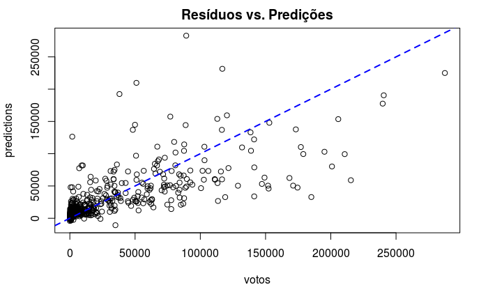

```r
  predictions = predict.lm(model_all_vars_2006, valid_2006)
  votos = valid_2006$votos

  predictions_plot = extendrange(c(votos, predictions)) +
    plot(votos, predictions, main="Resíduos vs. Predições") +
    abline(0, 1, col="blue", lty=2, lwd=2)
```

A linha azul representa o modelo e os pontos são as predições feitas com o set de dados de validação (diferente do set usado para treinar o modelo). A ideia aqui é que quanto mais próximos os pontos da linha azul, melhor o modelo. Como há pontos bastante distantes, então o modelo parece não descrever bem os dados.

#### Analisando resíduos

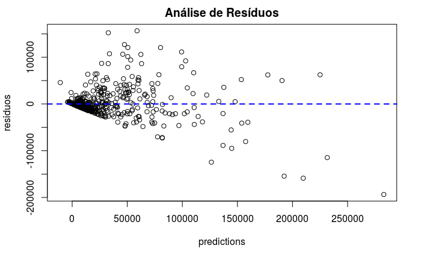

```r
residuos = valid_2006$votos - predictions
residuos_plot = plot(predictions, residuos, main="Análise de Resíduos") +
  abline(h=0,col="blue",lty=2,lwd=2)
```

É possível perceber que os resíduos não são simétricos e possuem um padrão de comportamento (o ideal é que fossem aleatórios). Isso indica que o modelo ainda precisa de aprimoramentos e transformações.

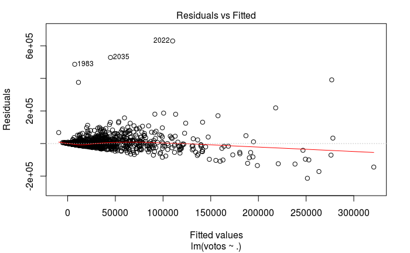

```r
residuos_fit_plot = plot(model_all_vars_2006, which = 1)
```

O objetivo deste gráfico é verificar a não existência de padrão no comportamento dos erros, já que esses erros devem ser aleatórios. Aqui novamente identifica-se padrão nos erros.

O próximo gráfico procura identificar se os resíduos têm distribuição normal:

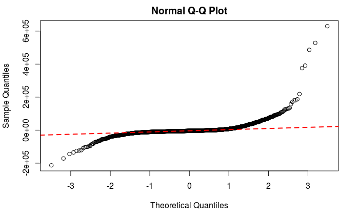

```r
normal_plot = qqnorm(model_all_vars_2006$residuals)
qqline(model_all_vars_2006$residuals, col = 2,lwd=2,lty=2)
```

Aqui vemos que os pontos estão muito desajustados à linha reta, o que não é a situação ideal. Perceba que os pontos se curvam nas extremidades. Isso pode significar que nossos dados possuem mais valores extremos do que esperado caso tivessem uma distribuição normal.

Sumarizando o modelo:

```r
summary(model_all_vars_2006)
```

```
Call:
lm(formula = votos ~ ., data = filtered_traind_data)

Residuals:
    Min      1Q  Median      3Q     Max
-213282   -8682   -4457     738  629746

Coefficients: (1 not defined because of singularities)
                                        Estimate Std. Error t value Pr(>|t|)
(Intercept)                            114.33034 6183.31607   0.018  0.98525
uf                                     -92.27640  105.07241  -0.878  0.37993
partido                               -181.35374   94.95068  -1.910  0.05628 .
quantidade_doacoes                     -36.36633  168.96426  -0.215  0.82961
quantidade_doadores                    333.79963  184.88470   1.805  0.07115 .
total_receita                           -0.16358    0.03049  -5.365 9.02e-08 ***
media_receita                            1.26002    0.14945   8.431  < 2e-16 ***
recursos_de_outros_candidatos.comites    0.06860    0.03222   2.129  0.03335 *
recursos_de_pessoas_fisicas              0.20945    0.03244   6.458 1.33e-10 ***
recursos_de_pessoas_juridicas            0.14312    0.02591   5.524 3.74e-08 ***
recursos_proprios                        0.07568    0.02722   2.780  0.00549 **
recursos_de_partido_politico                  NA         NA      NA       NA
quantidade_despesas                    -34.29644   18.69085  -1.835  0.06666 .
quantidade_fornecedores                 -2.77541   22.98789  -0.121  0.90391
total_despesa                            0.13985    0.01777   7.870 5.71e-15 ***
media_despesa                            0.04180    0.53900   0.078  0.93819
sexo                                  4811.78126 2428.41033   1.981  0.04767 *
grau                                   734.54909  465.12736   1.579  0.11444
estado_civil                          -446.26966  652.52800  -0.684  0.49411
ocupacao                               -32.69496   15.71190  -2.081  0.03757 *
---
Signif. codes:  0 ‘***’ 0.001 ‘**’ 0.01 ‘*’ 0.05 ‘.’ 0.1 ‘ ’ 1

Residual standard error: 35390 on 2043 degrees of freedom
  (352 observations deleted due to missingness)
Multiple R-squared:  0.4861,    Adjusted R-squared:  0.4815
F-statistic: 107.3 on 18 and 2043 DF,  p-value: < 2.2e-16
```

Este sumário trás dois importantes índices: o RSE (residual standard error) e o R² (R-squared). O primeiro fornece uma medida absoluta de falta de ajuste do modelo aos dados. Já o R² indica a proporção da variabilidade da variável alvo explicada pelo modelo. No caso do modelo acima, por exemplo, ele explica 48% dos dados, assim podemos afirmar que este modelo é razoável para explicar a quantidade de votos de um candidato.

### 2.2 Para eleições de 2010

Plotando os gráficos de diagnóstico:

```r
diagnostic_plots = function(model, valid_set) {

  Predictions = predict.lm(model, valid_set)
  Votos = valid_set$votos
  predictions_plot = extendrange(c(Votos, Predictions)) +
    plot(Votos, Predictions, main="Resíduos vs Predição") +
    abline(0, 1, col="blue", lty=2, lwd=2)
  predictions_plot

  Residuos = Votos - Predictions
  residuos_plot = plot(Predictions, Residuos, main="Análise de Resíduos") +
    abline(h=0,col="blue",lty=2,lwd=2)
  residuos_plot

  residuos_fit_plot = plot(model, which = 1)

  normal_plot = qqnorm(model$residuals)
  qqline(model$residuals, col = 2,lwd=2,lty=2)
}
```

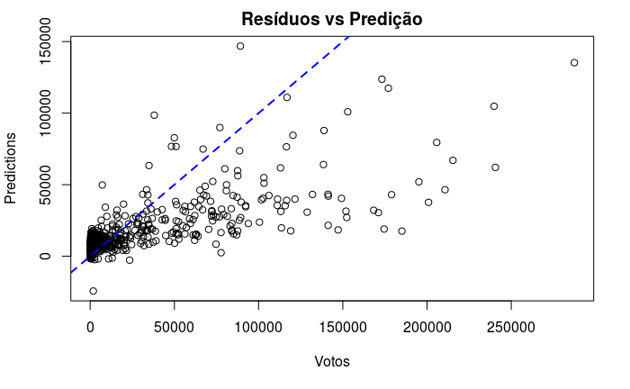

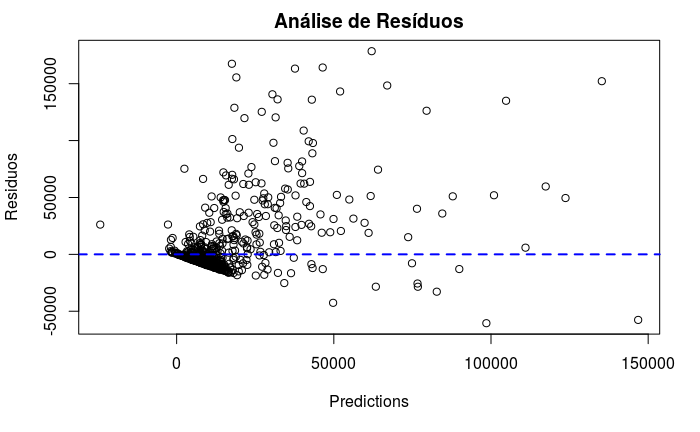

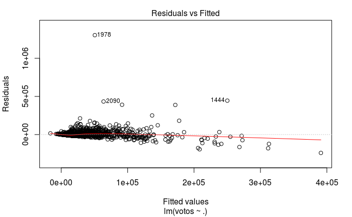

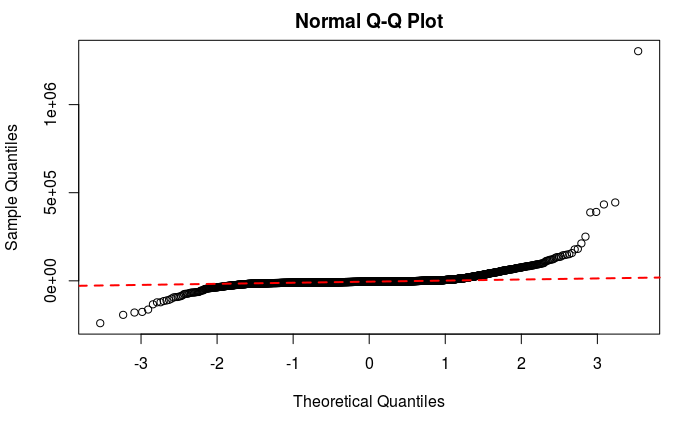

```r
diagnostic_plots(model_all_vars_2010, valid_2006)
```

Percebe-se que os mesmos problemas enfrentados para o modelo do ano de 2006 são encontrados para este modelo também (assimetria e padronização dos resíduos, comportamento foge da distribuição normal, etc).

Sumarizando:

```r
summary(model_all_vars_2010)
```

```
Call:
lm(formula = votos ~ ., data = filtered_traind_data)

Residuals:
    Min      1Q  Median      3Q     Max
-240420   -8884   -5136    -607 1303183

Coefficients: (1 not defined because of singularities)
                                        Estimate Std. Error t value Pr(>|t|)
(Intercept)                            9.154e+03  5.992e+03   1.528 0.126693
uf                                    -1.659e+02  1.113e+02  -1.490 0.136226
partido                               -1.661e+02  9.693e+01  -1.714 0.086714 .
quantidade_doacoes                    -9.354e+01  8.059e+01  -1.161 0.245887
quantidade_doadores                    1.422e+02  9.626e+01   1.477 0.139807
total_receita                         -3.152e-02  1.364e-02  -2.311 0.020922 *
media_receita                         -2.696e-01  6.927e-02  -3.892 0.000102 ***
recursos_de_outros_candidatos.comites  2.831e-02  8.358e-03   3.387 0.000718 ***
recursos_de_pessoas_fisicas            5.303e-02  1.322e-02   4.011 6.23e-05 ***
recursos_de_pessoas_juridicas          1.364e-03  7.807e-03   0.175 0.861330
recursos_proprios                     -2.315e-02  6.767e-03  -3.421 0.000635 ***
recursos_de_partido_politico                  NA         NA      NA       NA
quantidade_despesas                    2.010e+01  1.362e+01   1.476 0.139987
quantidade_fornecedores               -3.881e+01  1.614e+01  -2.404 0.016285 *
total_despesa                          1.065e-01  1.353e-02   7.866 5.45e-15 ***
media_despesa                          1.747e-01  1.044e-01   1.673 0.094459 .
sexo                                   3.752e+03  2.268e+03   1.654 0.098240 .
grau                                   6.504e+02  4.737e+02   1.373 0.169827
estado_civil                          -1.259e+03  6.383e+02  -1.973 0.048637 *
ocupacao                              -4.145e+01  1.712e+01  -2.421 0.015557 *
---
Signif. codes:  0 ‘***’ 0.001 ‘**’ 0.01 ‘*’ 0.05 ‘.’ 0.1 ‘ ’ 1

Residual standard error: 40780 on 2447 degrees of freedom
Multiple R-squared:  0.4172,    Adjusted R-squared:  0.4129
F-statistic: 97.33 on 18 and 2447 DF,  p-value: < 2.2e-16
```

O R² para os dados de 2010 é menor que aquele para os dados de 2006.

### Quais variáveis conseguem explicar melhor o número de votos?

Se retornarmos ao sumário dos modelos, perceberemos que muitas variáveis têm um p-valor maior que 0.05. Para essas variáveis, suas chances de estarem relacionadas à variável voto por aleatoriedade é muito alta. Desse modo, poderíamos ter um modelo com mesma significância porém mais simples se removêssemos essas variáveis com o p-valor maior que 0.05. Se assim procedermos, para 2006 ficaremos com:

- total_receita
- media_receita
- recursos_de_outros_candidatos.comites
- recursos_de_pessoas_fisicas
- recursos_de_pessoas_juridicas
- recursos_proprios
- total_despesa
- sexo
- ocupacao

Para responder à pergunta, é também interessante olhar a correlação entre a feature/variável independente e a variável alvo/dependent (nesse caos, votos). Faremos isso a seguir.

## 3. Todas as variáveis são úteis para os modelos de regressão? Há variáveis redudantes?

Para identificar se há variáveis redundantes, podemos avaliar a correlação entre elas. Se duas variáveis forem fortemente correlacioandas, então uma delas é redundante.

### Para 2006:

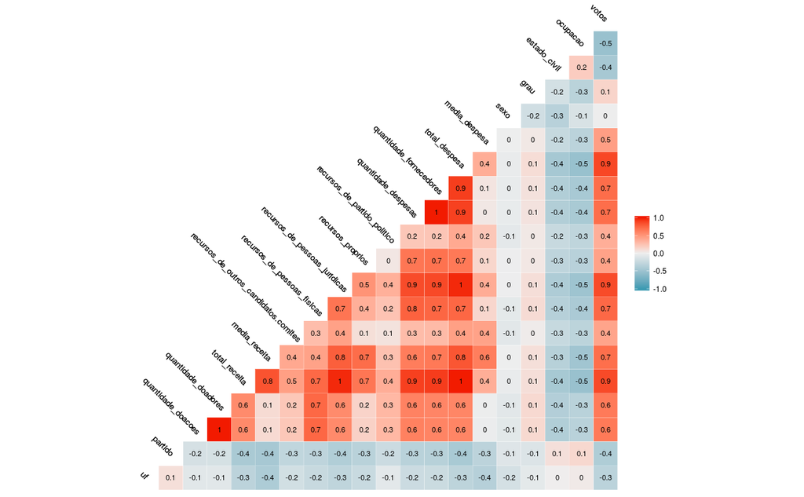

```r
library(GGally)
corr_plot = function(data) {
  corr = data %>% remove_non_related_vars %>% cor() %>% round(2)
  corr %>%
    GGally::ggcorr(label_size = 3, label = TRUE, label_color = "black", hjust = 0.925, size = 3.5, angle = -45)
}
corr_plot(elections_2006)
```

Olhando para a linha de total_receita, percebemos que está consideralvemente correlacionadas com muitas outras variáveis, por exemplo:

- media_receita (0.8)
- recursos_de_pessoas_fisicas (0.7)
- recursos_de_pessoas_juridicas (1)
- recursos_proprios (0.7)
- quantidade_despesas (0.9)
- quantidade_fornecedores (0.9)
- total_depesa (1)

Estamos usando o limite 0.7 para identificar redundância. Acima ou igual a esse valor estaremos classificando uma correlação como forte e portanto identificando uma relaçaõ redudante no contexto de nosso modelo.

Há muitas outras áreas em vermelho no gráfico, sugerindo que outras variáveis também possuem considerável correlaçaõ entre si, a exemplo de quantidade_despesas e quantidade_fornecedores (1).  
Se muitas variáveis independentes são redundantes, não podemos avaliar bem a participação de cada uma delas para explicar a variável alvo (no nosso caso, `votos`), pois diferentes variáveis têm o mesmo efeito na mesma parcela de dados da variável dependente (`voto`).

### Vamos agora avaliar considerando os dados de 2010:

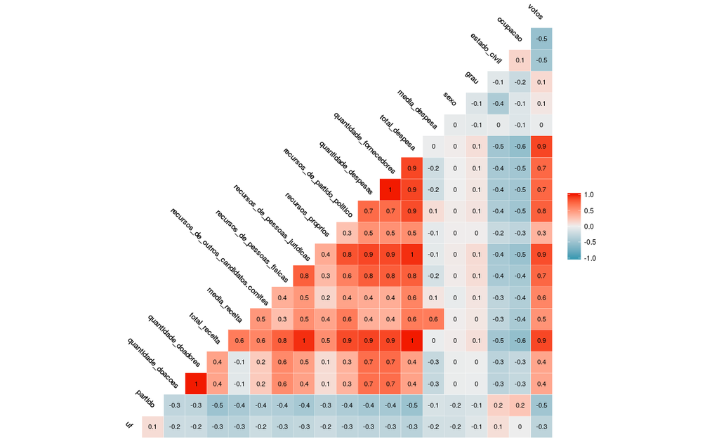

```r
corr_plot(elections_2010)
```

A situação é bastante parecida com o caso de 2006.

## 4. Construindo um novo modelo sem as variáveis redudantes

Existem alguns algortimos amplamente usados para realizar seleção de features para modelos, a exemplo de LASSO e Elastic Net. Para este relatório, contudo, por simplicidade, utilizamos algumas abordagens de caráter mais força bruta. Para decidir quais features redundantes não usar no nosso modelo, consideramos também o p-valor e a correlação da variável e com a variável alvo.

### Modelo para os dados de 2006

```r
input = train_2006 %>%
  remove_non_related_vars %>%
  select(votos, recursos_proprios, total_despesa, quantidade_doadores, recursos_de_pessoas_fisicas)
final_model_2006 = lm(data = input, formula = votos ~ .)
```

Avaliando RSE e R2:

```r
summary(final_model_2006)
```

```
Call:
lm(formula = votos ~ ., data = input)

Residuals:
    Min      1Q  Median      3Q     Max
-174667   -8659   -7423   -1635  651975

Coefficients:
                              Estimate Std. Error t value Pr(>|t|)
(Intercept)                  8.007e+03  9.401e+02   8.517  < 2e-16 ***
recursos_proprios           -4.197e-02  1.059e-02  -3.962 7.67e-05 ***
total_despesa                1.172e-01  4.702e-03  24.932  < 2e-16 ***
quantidade_doadores          1.734e+02  2.504e+01   6.924 5.87e-12 ***
recursos_de_pessoas_fisicas  3.497e-02  1.876e-02   1.864   0.0624 .
---
Signif. codes:  0 ‘***’ 0.001 ‘**’ 0.01 ‘*’ 0.05 ‘.’ 0.1 ‘ ’ 1

Residual standard error: 37200 on 2057 degrees of freedom
  (352 observations deleted due to missingness)
Multiple R-squared:  0.4281,    Adjusted R-squared:  0.427
F-statistic:   385 on 4 and 2057 DF,  p-value: < 2.2e-16
```

Em comparação ao modelo anterior para 2006, com todas mais variáveis, o RSE aumentou e o R² diminui aproximadamente 0.06. O modelo tornou-se um pouco menos significativo sem as variáveis redundantes.

### Modelo sem variáveis redundantes para os dados de 2010

```r
input = train_2010 %>%
  remove_non_related_vars %>%
  select(votos, total_despesa, recursos_de_outros_candidatos.comites, recursos_proprios, media_receita)
final_model_2010 = lm(data = input, formula = votos ~ .)
```

Avaliando RSE e R²:

```r
summary(final_model_2010)
```

```
Call:
lm(formula = votos ~ ., data = input)

Residuals:
    Min      1Q  Median      3Q     Max
-242487   -8225   -7353   -3347 1298929

Coefficients:
                                        Estimate Std. Error t value Pr(>|t|)
(Intercept)                            8.528e+03  9.090e+02   9.382  < 2e-16 ***
total_despesa                          7.380e-02  2.392e-03  30.849  < 2e-16 ***
recursos_de_outros_candidatos.comites  2.703e-02  6.570e-03   4.113 4.03e-05 ***
recursos_proprios                     -3.597e-02  4.957e-03  -7.257 5.27e-13 ***
media_receita                         -2.183e-01  5.014e-02  -4.354 1.39e-05 ***
---
Signif. codes:  0 ‘***’ 0.001 ‘**’ 0.01 ‘*’ 0.05 ‘.’ 0.1 ‘ ’ 1

Residual standard error: 41350 on 2461 degrees of freedom
Multiple R-squared:  0.3976,    Adjusted R-squared:  0.3966
F-statistic: 406.1 on 4 and 2461 DF,  p-value: < 2.2e-16
```

Para 2010, o impacto de tirar as variáveis redundantes foi muito insignificativo. O RSE aumentou pouco e o R² diminui pouquíssimo. Dado que o modelo tornou-se muito mais simples, retirar as variáveis redundantes foi bom.

## 5. Construindo uma regressão considerando os anos 2006 e 2010 em conjunto, que diferenças/semelhanças você percebe em relação aos modelos individuais por ano?

Separando entre dados de treino, validação e teste:

```r
set.seed(123)
splitted = create_train_validate_test(elections_2006_2010)
train_set = splitted[[1]]
valid_set = splitted[[2]]
test_set = splitted[[3]]
```

Construindo o modelo:

```r
linear_regression_model = lm(data = train_set,
                             formula =
                               votos ~
                               total_despesa +
                               sqrt(total_despesa) +
                               quantidade_doadores +
                               recursos_proprios +
                               total_despesa * quantidade_doadores +
                               total_despesa * recursos_proprios)
```

Avaliando o modelo:

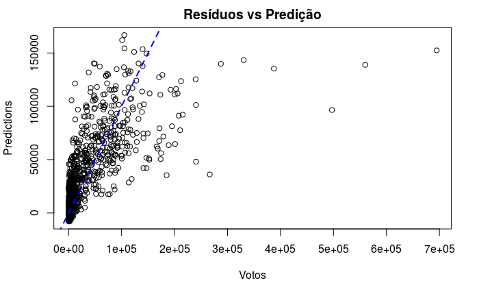

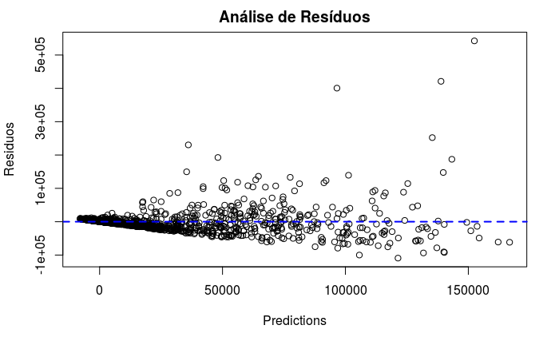

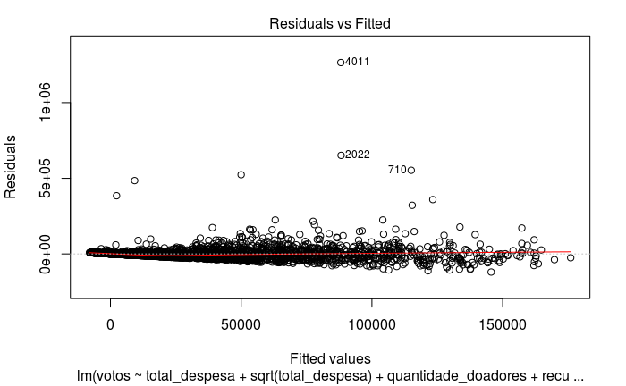

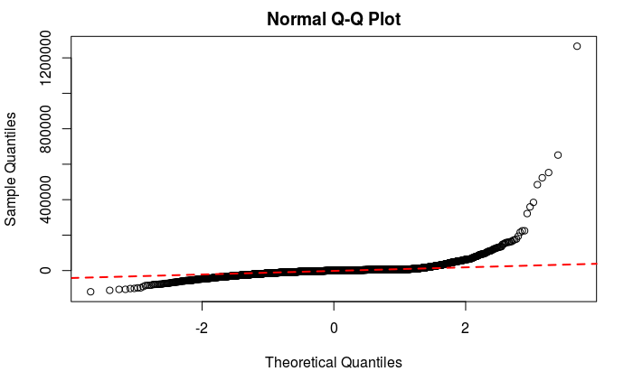

```r
diagnostic_plots(linear_regression_model, valid_set)
```

```r
summary(linear_regression_model)
```

```
Call:
lm(formula = votos ~ total_despesa + sqrt(total_despesa) + quantidade_doadores +
    recursos_proprios + total_despesa * quantidade_doadores +
    total_despesa * recursos_proprios, data = train_set)

Residuals:
    Min      1Q  Median      3Q     Max
-119755   -8759    -254    4828 1265715

Coefficients:
                                    Estimate Std. Error t value Pr(>|t|)
(Intercept)                       -8.043e+03  8.487e+02  -9.477  < 2e-16 ***
total_despesa                     -2.304e-02  4.126e-03  -5.584 2.49e-08 ***
sqrt(total_despesa)                1.374e+02  5.384e+00  25.514  < 2e-16 ***
quantidade_doadores                8.089e+01  1.566e+01   5.165 2.51e-07 ***
recursos_proprios                 -4.853e-02  7.670e-03  -6.327 2.74e-10 ***
total_despesa:quantidade_doadores -2.689e-05  5.292e-06  -5.081 3.90e-07 ***
total_despesa:recursos_proprios    6.051e-09  2.233e-09   2.710  0.00675 **
---
Signif. codes:  0 ‘***’ 0.001 ‘**’ 0.01 ‘*’ 0.05 ‘.’ 0.1 ‘ ’ 1

Residual standard error: 35960 on 4469 degrees of freedom
Multiple R-squared:  0.479, Adjusted R-squared:  0.4783
F-statistic: 684.7 on 6 and 4469 DF,  p-value: < 2.2e-16
```

A análise dos resíduos indica que o modelo não teve melhoras significantes. A distribuíção dos resíduos ainda foge da distribuição normal nas extremidades. Mas os índices RSE e R² indicam que o modelo pode obter resultados melhores.